# **Universidad de Sonora** Sorteo 13 Lotes

El presente documento técnico contiene los algoritmos computacionales (usando el lenguaje de programación Python) y los fundamentos probabilísticos que se utilizaron para la realización el Sorteo 13 Lotes, de la Universidad de Sonora, y que garantizan la aleatoriedad en la asignación de números, así como en el sorteo de cada uno de los trece lotes disponibles para sortear entre el listado de participantes acreditados por la Tesorería General de la Universidad de Sonora.

El **equipo de trabajo** responsable del diseño, validación e implementación del presente programa, así como de la logística de su presentación a través de la plataforma Microsoft TEAMS, está integrado por:

- Espinoza Fierro, Jesús Francisco (MTC, Departamento de Matemáticas)
- Figueroa Preciado, Gudelia (MTC, Departamento de Matemáticas)
- Hernández Amador, Pedro Andrés (Estudiante de la Licenciatura en Ciencias de la Computación)
- Hernández Amador, Rosalía Guadalupe (MTC, Departamento de Matemáticas)
- Soto Barrera, Juan Pablo (MTC, Departamento de Matemáticas)

Por cuestiones de organización, se ha dividido el presente documento en tres fases, las cuáles se describen a continuación:

- **Fase 1:** Lectura del listado de participantes en el sorteo y del listado de los números de lotes que se sortearán.
- **Fase 2:** Asignación aleatoria de los números a cada uno de los participantes, tantos cómo su número de años de antigüedad.
- **Fase 3:** Sorteo de cada uno de los trece lotes, entre el total de números asignados a los participantes.

# **Fase 1:** Lectura del listado de participantes y números de lotes

## Librerías necesarias

A fin de que los subsecuentes algoritmos computacionales se puedan ejecutar correctamente, se importan las siguientes librerías estándar de Python:

```python
# Librería para el manejo de los datos
import pandas as pd

# Librería para las selecciones aleatorias
import random
```

## Lectura del archivo de los participantes en el Sorteo 13 Lotes, de la Universidad de Sonora

El equipo de trabajo, cuyos integrantes se señalaron al inicio de este documento, recibió la lista de participantes para el Sorte 13 Lotes, la cual fue recibida en el correo gudelia.figueroa@unison.mx, con remitente carlos.yocupicio@unison.mx, el día miércoles 19 de mayo de 2021, 07:55 p. m.

El código de integridad del archivo recibido "PARTICIPANTES SORTEO 13 LOTES UNISON.csv", calculado con el algorítmo SHA256 es: **ae46daa9bb4ad9b3741eb7462b4799f2b0acce4796ff3eef1e69fc8ac8313198**.

A continuación, se procede a la lectura de los datos contenidos en el archivo "PARTICIPANTES SORTEO 13 LOTES UNISON.csv", el cual contiene las siguientes dos columnas no vacías: "Empleado" y "Antigüedad". En el documento existe una tercera columna, la cual se encuentra vacía.

```python
participantes = pd.read_csv('./datos/PARTICIPANTES SORTEO 13 LOTES UNISON.csv',
                            encoding = 'unicode_escape')

# Se configura la impresión completa de la lista de participantes.
pd.set_option('display.max_rows', None)
participantes
```

|  | Empleado | Antigüedad | Unnamed: 2 |
| --- | --- | --- | --- |
| 0 | 97134 | 10 | NaN |
| 1 | 33154 | 6 | NaN |
| 2 | 33524 | 5 | NaN |
| 3 | 32799 | 7 | NaN |
| 4 | 97113 | 12 | NaN |
| 5 | 31365 | 6 | NaN |
| 6 | 33821 | 4 | NaN |
| 7 | 33826 | 4 | NaN |
| 8 | 27139 | 27 | NaN |
| 9 | 33310 | 6 | NaN |
| 10 | 33579 | 4 | NaN |
| 11 | 97172 | 10 | NaN |
| 12 | 31609 | 10 | NaN |
| 13 | 33966 | 3 | NaN |
| 14 | 97092 | 12 | NaN |
| 15 | 34065 | 3 | NaN |
| 16 | 31902 | 10 | NaN |
| 17 | 33224 | 6 | NaN |
| 18 | 32429 | 9 | NaN |
| 19 | 33285 | 6 | NaN |
| 20 | 22722 | 34 | NaN |
| 21 | 33459 | 5 | NaN |
| 22 | 33312 | 5 | NaN |
| 23 | 32826 | 7 | NaN |
| 24 | 31032 | 13 | NaN |
| 25 | 29099 | 23 | NaN |
| 26 | 33223 | 5 | NaN |
| 27 | 33474 | 5 | NaN |
| 28 | 32535 | 8 | NaN |
| 29 | 32375 | 7 | NaN |

[output cut: 58 more lines]

Con la finalidad de ajustar los datos proporcionados al formato que el software los utiliza, se renombran de las columnas (removiendo las diéresis) y, los registros se ordenan de mayor a menor de acuerdo al número de años de antigüedad de los participantes.

```python
# Se renombran las columnas:
participantes.columns = ['num_empleado', 'antiguedad', '']

# Se elimina la última columna vacía, es decir, conservamos con las primeras dos:
participantes = participantes[['num_empleado', 'antiguedad']]

# Se ordenan a los participantes de mayor a menor de acuerdo a su antiguedad:
participantes = participantes.sort_values(by=['antiguedad'], ascending=[False])

# Se reinicia la columna de índices:
participantes.reset_index(drop=True, inplace=True)
participantes
```

|  | num_empleado | antiguedad |
| --- | --- | --- |
| 0 | 22722 | 34 |
| 1 | 24321 | 32 |
| 2 | 26470 | 28 |
| 3 | 27139 | 27 |
| 4 | 28526 | 25 |
| 5 | 29099 | 23 |
| 6 | 28491 | 21 |
| 7 | 28837 | 21 |
| 8 | 29082 | 21 |
| 9 | 29276 | 20 |
| 10 | 29228 | 19 |
| 11 | 30095 | 18 |
| 12 | 29759 | 18 |
| 13 | 29678 | 18 |
| 14 | 30025 | 17 |
| 15 | 29969 | 17 |
| 16 | 30140 | 16 |
| 17 | 29667 | 16 |
| 18 | 30318 | 16 |
| 19 | 29671 | 15 |
| 20 | 30794 | 14 |
| 21 | 31038 | 13 |
| 22 | 31032 | 13 |
| 23 | 97221 | 12 |
| 24 | 97090 | 12 |
| 25 | 96828 | 12 |
| 26 | 97113 | 12 |
| 27 | 31173 | 12 |
| 28 | 97088 | 12 |
| 29 | 31009 | 12 |

[output cut: 58 more lines]

## Listado de los lotes en el Sorteo 13 Lotes, de la Universidad de Sonora

El listado de los lotes, obtenido del PLANO DE LOTIFICACIÓN Y USO DE SUELO, fue capturado por el equipo trabajo, en el documento "LOTES.csv", cuya lectura e impresión se muestra debajo de la siguiente imagen, que contiene los números de lotes a sortear.

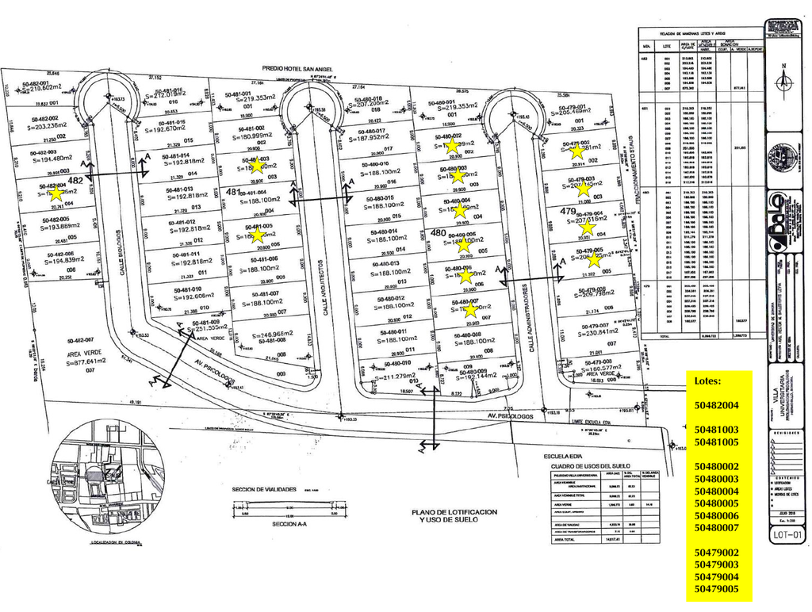

```python
terrenos = pd.read_csv('./datos/LOTES.csv')
terrenos
```

|  | Numero_Lote |
| --- | --- |
| 0 | 50482004 |
| 1 | 50481003 |
| 2 | 50481005 |
| 3 | 50480002 |
| 4 | 50480003 |
| 5 | 50480004 |
| 6 | 50480005 |
| 7 | 50480006 |
| 8 | 50480007 |
| 9 | 50479002 |
| 10 | 50479003 |
| 11 | 50479004 |
| 12 | 50479005 |